# Part 4: Applying UMAP to the Claims Text Data

```r
library(tidyverse)

# Produced by scripts/umap-model-on-claims.R
load("~/Desktop/PSTAT197A/vignette-umap/data/processed/claims-results.RData")

pal <- c("No relevant content" = "#7570b3",
         "Relevant claim content" = "#d95f02")
pct <- function(x) scales::percent(x, accuracy = 0.1)
```

## Step 1: Reintroduce the dataset

The Module 2 data are scraped web pages. Each page is labeled either as containing relevant claim content or as having no relevant content, so this is a binary text classification problem. Raw HTML is not something UMAP can use directly, so the first job is turning each page into numbers.

```r
class_counts |>
  rename(`Class` = class, `Documents` = n_docs) |>
  knitr::kable()
```

| Class | Documents |
| --- | --- |
| No relevant content | 896 |
| Relevant claim content | 1075 |

## Step 2: Prepare the data

We reuse the Module 2 preprocessing: parse the HTML, clean the text, drop stop words, lemmatize, and compute a TF-IDF weight for every word in every document. Each document becomes one row, and each word becomes one column.

```r
data_summary |>
  transmute(
    Documents = n_docs,
    `TF-IDF features (words)` = n_features,
    `Training docs` = n_train,
    `Test docs` = n_test,
    `Share of entries equal to 0` = pct(pct_zero)
  ) |>
  knitr::kable(format.args = list(big.mark = ","))
```

| Documents | TF-IDF features (words) | Training docs | Test docs | Share of entries equal to 0 |
| --- | --- | --- | --- | --- |
| 1,971 | 5,367 | 1,576 | 395 | 98.3% |

That is a very high-dimensional, mostly empty matrix: far more columns than any plot can show. We dropped words appearing in fewer than 5 training documents, then split 80/20 so we can test on pages UMAP never saw.

## Step 3: Apply UMAP

We use cosine distance, which suits TF-IDF vectors because it compares the direction of word usage rather than document length.

```r
# 2D embedding of every document, for the picture
umap_2d <- umap(tfidf_matrix, n_neighbors = 15, n_components = 2,
                min_dist = 0.1, metric = "cosine")

# 10D embedding fit on training docs only, used as extracted features
umap_model <- umap(tfidf_matrix[train_idx, ], n_neighbors = 15,
                   n_components = 10, min_dist = 0.1,
                   metric = "cosine", ret_model = TRUE)

# Place unseen test documents into the same space
test_embedding <- umap_transform(tfidf_matrix[test_idx, ], umap_model)
```

The 2D version is for seeing the data. The 10D version, fit on training pages only and then applied to test pages with `umap_transform()`, is for using UMAP as **feature extraction**.

## Step 4: Visualize the results

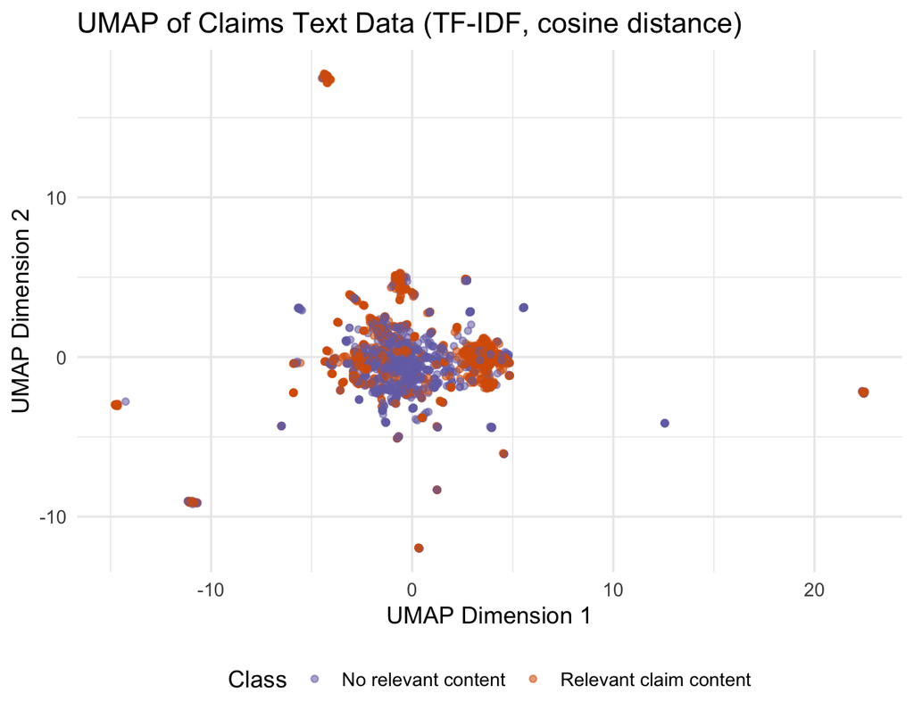

```r
ggplot(umap_df, aes(UMAP1, UMAP2, color = class)) +
  geom_point(alpha = 0.55, size = 1.4) +
  scale_color_manual(values = pal) +
  labs(title = "UMAP of Claims Text Data (TF-IDF, cosine distance)",
       x = "UMAP Dimension 1", y = "UMAP Dimension 2",
       color = "Class") +
  theme_minimal(base_size = 13) +
  theme(legend.position = "bottom")
```

UMAP never saw the labels, yet pages of the same class tend to land near each other. Overlap tells us the two classes share vocabulary. As in the small example, the axes have no meaning on their own and distances between far-apart groups should not be over-interpreted.

## Step 5: Evaluate the results

A pretty picture is not enough. The real test is whether the 10 extracted features keep the information needed to classify held-out pages. We predict each test page’s class from its 15 nearest training pages (k-nearest neighbors), using three different feature sets.

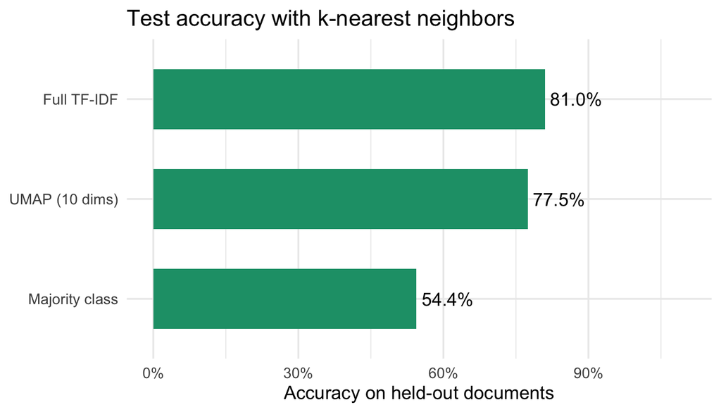

```r
eval_table |>
  mutate(features = fct_reorder(features, accuracy)) |>
  ggplot(aes(accuracy, features)) +
  geom_col(fill = "#1b9e77", width = 0.6) +
  geom_text(aes(label = pct(accuracy)), hjust = -0.1, size = 4.5) +
  scale_x_continuous(limits = c(0, 1.1), labels = scales::percent) +
  labs(title = "Test accuracy with k-nearest neighbors",
       x = "Accuracy on held-out documents", y = NULL) +
  theme_minimal(base_size = 13)
```

```r
confusion_umap |>
  pivot_wider(names_from = predicted, values_from = Freq) |>
  knitr::kable(caption = "Confusion matrix, UMAP features (rows = truth)")
```

Confusion matrix, UMAP features (rows = truth)

| truth | No relevant content | Relevant claim content |
| --- | --- | --- |
| No relevant content | 123 | 57 |
| Relevant claim content | 32 | 183 |

## Speaker notes (about 1.5 to 2 minutes)

The numbers below fill in from `claims-results.RData` when the file is rendered.

**Step 1, dataset (about 15 sec).** “Our dataset is the Module 2 claims data: web pages labeled as containing relevant claim content or not. It’s a binary text classification problem.”

**Step 2, prepare (about 20 sec).** “Raw HTML isn’t usable, so we parse and clean it and turn every page into TF-IDF weights. That gives 1,971 documents and 5,367 features, and 98.3% of the entries are zero. We held out 20% of the pages for testing.”

**Step 3, apply UMAP (about 20 sec).** “We run UMAP with cosine distance. One run goes down to 2 dimensions for plotting. A second run, fit on training pages only, goes down to 10 dimensions, and we use `umap_transform` to place the test pages in that same space. That second run is feature extraction.”

**Step 5, evaluate (about 30 sec).** “To check this isn’t just a nice picture, we classify held-out pages with nearest neighbors. Guessing the majority class gets 54.4%. Using all 5,367 TF-IDF features gets 81.0%. Using only 10 UMAP features gets 77.5%. So 10 extracted numbers per page carry the information we need, which is what makes UMAP useful beyond visualization.”

*Edit the Step 5 wording after rendering if the UMAP result is not what you expected, so the sentence matches the actual numbers.*